# buoy_weight

Hayden Vega

2024-10-29

### Setup

```r
library(tidyverse)
library(readxl)
library(janitor)
library(here)
library(ggplot2)
library(broom)
library(ggpubr)
library(lme4)
library(lmerTest)
library(car)
library(emmeans)
library(broom.mixed)
library(knitr)          # kable() for table rendering
library(kableExtra)
```

```r
buoy_data <- read.csv(here("data", "fish_regen_buoyantweight (1).csv"))
coral_delta <- read.csv(here("data", "coral_delta.csv"))
```

```r
buoy_data%>%
  mutate(density_stopper = (air_weight_g * 0.9965)/(air_weight_g - fresh_weight_g))%>%
  mutate(density_sw = (air_weight_g - salt_weight_g)/ (air_weight_g / density_stopper))%>%
  mutate(dry_mass = bouyantweight_g / (1 - (density_sw/density_aragonite)))%>%
  mutate(coral_vol = (dry_mass / (density_aragonite - density_sw))) -> skeletal.mass
```

# Allometric linear models

This section contains code for allometric linear models.

My big question is am I on the right track here? Or are there transformations that I am missing? Also is lm the correct model to run? Should we incorporate other variables into our models?

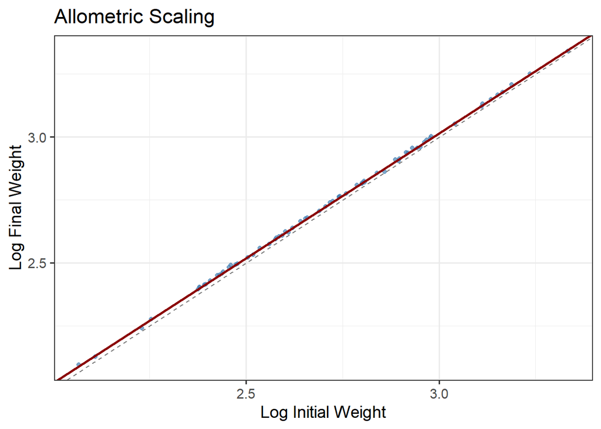

```r
     #                        Data Wrangling                       ~~~
     #~~~~~~~~~~~~~~~~~~~~~~~~~~~~~~~~~~~~~~~~~~~~~~~~~~~~~~~~~~~~~~~~

#Filter data to exclude erroneous outlier (coral 45) and extranneous columns. Pivot to create columns for initial and final buoyant weight.
log_data <- buoy_data %>%
  filter(coral_id != 45) %>%   #remove 45
  select(coral_id, date, bouyantweight_g, wound, fish) %>%  # keep only relevant columns
  pivot_wider(names_from = date, values_from = bouyantweight_g) %>% #initial and final to columns, values from buoyantweight
  rename(
    initial_weight = initial, #renaming for clarity
    final_weight = final
  ) %>%
  mutate(delta_mass = final_weight - initial_weight) #calculating delta

# Filter data for unwounded corals and no fish treatment
log_df <- log_data %>%
  #filter(wound == "No Wound", fish == "No Fish") %>%
  mutate(
    log_i_weight = log(initial_weight),
    log_f_weight = log(final_weight)
  )
#...............................................................................
#                                                                              .
#  Should we log only the "no wound, no fish" corals?                           .
#                                                                              .
#...............................................................................

b_values_df <- log_df %>%
  #group_by(coral_id) %>% #fish treatment specific
  do({
    model <- lm(log_f_weight ~ log_i_weight, data = .)
    tidy_model <- broom::tidy(model, conf.int = TRUE)
    intercept_row <- tidy_model[1, ]
    slope_row <- tidy_model[2, ]
    tibble(
      intercept = intercept_row$estimate,
      intercept_conf.low = intercept_row$conf.low,
      intercept_conf.high = intercept_row$conf.high,
      b_value = slope_row$estimate,
      b_conf.low = slope_row$conf.low,
      b_conf.high = slope_row$conf.high
    )
  })

log_df <- log_df %>%
  cross_join(b_values_df)

log_df %>%
  ggplot(aes(x = log_i_weight, y = log_f_weight)) +
  geom_point(alpha = 0.7, color = "steelblue") +
  geom_abline(aes(intercept = intercept, slope = b_value), color = "darkred", size = 1) +
  geom_abline(intercept = 0, slope = 1, linetype = "dashed", color = "grey50") +
  labs(
    title = "Allometric Scaling",
    x = "Log Initial Weight",
    y = "Log Final Weight"
  ) +
  theme_bw(base_size = 14)
```

## Linear model of growth ratio as a function of wound and fish treatments

```r
#Note, no tank random effect because it's not in the data. RUH ROH
log_df <- log_df %>%
  mutate(growth_ratio = final_weight / initial_weight)

growth_lm_interaction <- lm(growth_ratio~fish * wound , data = log_df )
summary(growth_lm_interaction)
```

```
##
## Call:
## lm(formula = growth_ratio ~ fish * wound, data = log_df)
##
## Residuals:
##        Min         1Q     Median         3Q        Max
## -0.0147863 -0.0027361  0.0007927  0.0035105  0.0125345
##
## Coefficients:
##                            Estimate Std. Error t value Pr(>|t|)
## (Intercept)                1.020178   0.001621 629.260   <2e-16 ***
## fishNo Fish               -0.002519   0.002293  -1.099    0.276
## woundNo Wound             -0.002240   0.002349  -0.953    0.344
## woundSmall                -0.001563   0.002244  -0.696    0.489
## fishNo Fish:woundNo Wound  0.002326   0.003249   0.716    0.477
## fishNo Fish:woundSmall     0.003244   0.003174   1.022    0.311
## ---
## Signif. codes:  0 '***' 0.001 '**' 0.01 '*' 0.05 '.' 0.1 ' ' 1
##
## Residual standard error: 0.005377 on 62 degrees of freedom
## Multiple R-squared:  0.03074,    Adjusted R-squared:  -0.04742
## F-statistic: 0.3933 on 5 and 62 DF,  p-value: 0.8516
```

```r
anova(growth_lm_interaction, test = "Chisq")
```

```
## Analysis of Variance Table
##
## Response: growth_ratio
##            Df     Sum Sq    Mean Sq F value Pr(>F)
## fish        1 0.00000754 7.5394e-06  0.2608 0.6114
## wound       2 0.00001763 8.8160e-06  0.3049 0.7383
## fish:wound  2 0.00003169 1.5843e-05  0.5480 0.5809
## Residuals  62 0.00179257 2.8912e-05
```

```r
growth_lm_no_int <- lm(growth_ratio~ fish + wound , data = log_df)
anova(growth_lm_no_int, test = "Chisq")
```

```
## Analysis of Variance Table
##
## Response: growth_ratio
##           Df     Sum Sq    Mean Sq F value Pr(>F)
## fish       1 0.00000754 7.5394e-06  0.2645 0.6088
## wound      2 0.00001763 8.8160e-06  0.3093 0.7351
## Residuals 64 0.00182426 2.8504e-05
```

```r
growth_no_wound <- lm(growth_ratio ~ fish , data = log_df)
anova(growth_no_wound, test = "Chisq")
```

```
## Analysis of Variance Table
##
## Response: growth_ratio
##           Df     Sum Sq    Mean Sq F value Pr(>F)
## fish       1 0.00000754 7.5394e-06  0.2702  0.605
## Residuals 66 0.00184189 2.7907e-05
```

```r
growth_no_fish <- lm(growth_ratio~wound , data = log_df)
anova(growth_no_fish, test = "Chisq")
```

```
## Analysis of Variance Table
##
## Response: growth_ratio
##           Df     Sum Sq    Mean Sq F value Pr(>F)
## wound      2 0.00001859 9.2965e-06  0.3301 0.7201
## Residuals 65 0.00183083 2.8167e-05
```

```r
#...............................................................................
#                                                                              .
#  It seems that neither fish nor wounding has a significant effect on growth  .
#                                                                              .
#...............................................................................
```

### Quantifying the best fitting model formula

This section contains my poor attempt to try and use the framework in simulating_wound_data.qmd to view how well the differing formulas fit the trends. My graph currently yields a big old blank.

This part was for giggles, so I have a lot of questions; the most important being: is this even useful? Could we just use AIC to test for best fitting models or the anova outputs? My code doesn’t work, and I think it’s because it doesn’t fit with what our goals are for these growth data. Is validating the fit beyond the anova outputs necessary?

```r
lrt_int <- anova(growth_lm_no_int, growth_lm_interaction, test = "Chisq")

# B) Test for fish main effect: does adding fish improve fit?
lrt_f   <- anova(growth_no_fish, growth_lm_no_int, test = "Chisq")

# C) Test for wound_size_cat main effect: does adding wound_size_cat improve fit?
lrt_s   <- anova(growth_no_wound, growth_lm_no_int, test = "Chisq")


coef_df <- tidy(growth_lm_interaction, effects = "fixed") %>%
  rename(
    term     = term,
    Estimate = estimate,
    SE       = std.error
  )

lrt_stats <- tribble(
  ~test_term,          ~LR.chisq,       ~Df, ~p_LRT,
  "Interaction",        lrt_int$Chisq[2], lrt_int$Df[2], lrt_int$`Pr(>Chisq)`[2],
  "Fish effect",        lrt_f$Chisq[2],   lrt_f$Df[2],   lrt_f$`Pr(>Chisq)`[2],
  "Wound size category",lrt_s$Chisq[2],   lrt_s$Df[2],   lrt_s$`Pr(>Chisq)`[2]
)

# 5c. Map each coefficient term to its corresponding LRT test label:
#     - fishpresent → "Fish effect"
#     - wound_size_catlarge → "Wound size category"
#     - fishpresent:wound_size_catlarge → "Interaction"
results_df <- coef_df %>%
  mutate(
    test_term = case_when(
      term == "fishNo Fish"                            ~ "Fish effect",
      term == "woundSmall"                    ~ "Wound size category",
      term == "fishNo Fish:woundSmall"        ~ "Interaction",
      TRUE                                             ~ NA_character_
    )
  ) %>%
  # Join with LRT stats by matching on test_term
  left_join(lrt_stats, by = "test_term") %>%
  # We only keep rows where a test_term exists (drop the intercept)
  filter(!is.na(test_term)) %>%
  # Select and order the columns we want in the final table
  select(term, Estimate, SE, LR.chisq, Df, p_LRT)

results_df %>%
  rename(
    ChiSq = LR.chisq,
    p     = p_LRT
  ) %>%
  kable(
    caption = "Table 1. GLMM Fixed Effects and Manual LRT χ² Tests",
    digits  = c(NA, 2, 2, 2, 0, 3)
  ) %>%
  kable_styling(full_width = FALSE, position = "center")
```

| term | Estimate | SE | ChiSq | Df | p |
| --- | --- | --- | --- | --- | --- |
| fishNo Fish | 0 | 0 | NULL | 1 | NULL |
| woundSmall | 0 | 0 | NULL | 2 | NULL |
| fishNo Fish:woundSmall | 0 | 0 | NULL | 2 | NULL |

```r
#  select(species, summary) %>%
 # unnest(summary)
```

## OLD CODE - ignore

```r
# log_data <- buoy_data %>%
#   filter(coral_id != 45) %>%
#   pivot_wider(
#     id_cols = coral_id,
#     names_from = date,
#     values_from = bouyantweight_g
#   )
#
# # Filter data for unwounded corals and no fish treatment
# allometry_df <- df %>%
#   filter(wound_raw == "not wounded", treatment == "no fish") %>%
#   mutate(
#     log_i_weight = log(i.weight),
#     log_f_weight = log(f.weight)
#   )
# log_data %>%
#   ggplot(aes(initial, final))+
#   geom_point()
#
# 0.991493 + .002019 * 2
#
#
# #This graph
# skeletal.mass %>%
#   ggplot(aes(date, bouyantweight_g, color = fish, fill = wound))+
#   geom_boxplot()
```

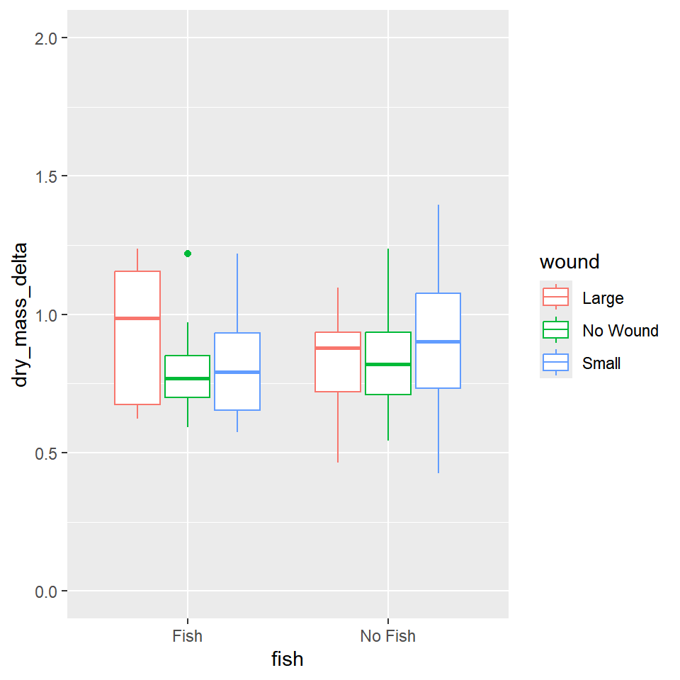

```r
coral_delta %>%
  ggplot(aes(fish, dry_mass_delta, color = wound))+
  geom_boxplot()+
  coord_cartesian(ylim = c(0, 2))
```

```r
# coral_delta %>%
#   ggplot(aes(fish, vol_delta, color = wound))+
#   geom_boxplot()+
#   coord_cartesian(ylim = c(0, 2))
```